# 單因子 ANOVA 與多重比較

Week 11 · Part 2 · R 實習

## 確認 R 找得到資料

把多重比較起始 QMD與教學調整 CSV放在同一個資料夾。在 RStudio 把工作目錄指到這個資料夾，再從 QMD 第一個區塊開始執行。

```r
library(dplyr)
getwd()
file.exists("week11_correction_demo_reconstructed.csv")
head(chickwts)
```

`file.exists()` 回傳 `TRUE` 就能繼續。`chickwts` 是 R 內建資料，不用另存檔。若出現 `FALSE`，比對工作目錄與檔名。

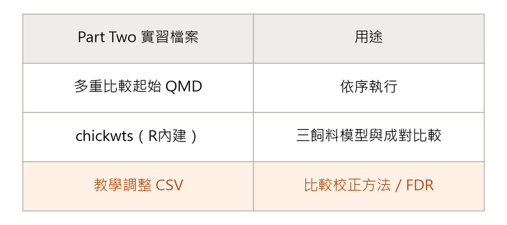

兩個案例分別用 R 內建的 chickwts 與教學調整 CSV。

IMS 2e §22.5 練習 5（R `chickwts`）；教學調整資料改編自 Rosner 8e Table 12.33（僅減重組平均改為 6.4）。

## 飼料例｜先取出三組，確認讀到什麼

```r
str(chickwts)
feeds <- c("casein", "linseed", "sunflower")
three <- chickwts |> filter(feed %in% feeds)
nrow(three)
head(three)
```

`chickwts` 有 71 列、六種飼料；篩選這三種飼料後應有 36 列。每列是一隻小雞。

| 欄位 | 內容 |
| --- | --- |
| `weight` | 六週齡體重（g） |
| `feed` | 飼料：酪蛋白（`casein`）、亞麻籽（`linseed`）、葵花籽（`sunflower`）等 |

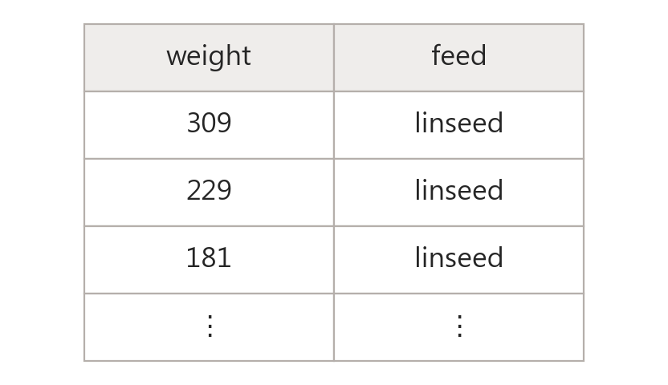

取出三組後的前三列；每列是一隻小雞。

IMS 2e §22.5 練習 5；R `?chickwts`；dplyr `?filter`。從六種飼料中取三組比較。

## 把飼料重新設為因子，再算組平均

```r
three <- three |> mutate(feed = factor(feed, levels = feeds))
feed_summary <- three |>
  group_by(feed) |>
  summarise(
    n = n(), mean_weight = mean(weight), sd_weight = sd(weight),
    ss_within = sum((weight - mean(weight))^2), .groups = "drop"
  )
feed_summary
```

`mutate()` 重設飼料因子的順序。`group_by()` 和 `summarise()` 讓每種飼料各占一列。三組各 12 隻，平均 **323.6、218.8、328.9 g**；標準差 64.4、52.2、48.8，最大與最小相差不到 1.4 倍。

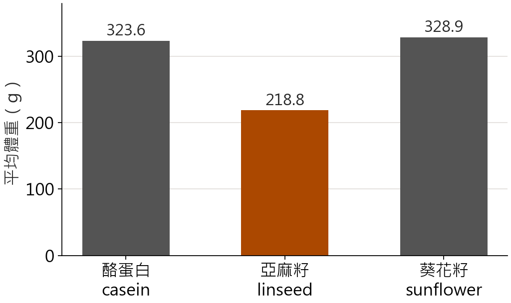

長條長度對應各組平均體重。

IMS 2e §22.3.4（ANOVA 條件）、§22.5 練習 5；R `?factor`；dplyr `?mutate`、`?summarise`。

## 單因子 ANOVA｜一張表讀出整體檢定

```r
fit <- aov(weight ~ feed, data = three)
summary(fit)
```

| 項目 | Df | Sum Sq | Mean Sq | F value | Pr(>F) |
| --- | --- | --- | --- | --- | --- |
| feed | 2 | 92621 | 46310 | 14.99 | 2.33e-05 |
| Residuals | 33 | 101918 | 3088 |  |  |

R 4.4.3 預設只印到整數；未四捨五入時 $F=46310.33/3088.43\approx14.99$。`weight ~ feed` 用三種飼料解釋體重差異；拒絕三個母體平均都相同後，要靠成對比較定位差異。

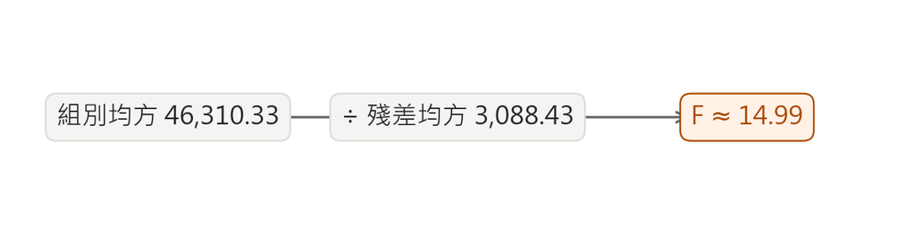

F 是組別均方除以殘差均方。

IMS 2e §22.3.3（讀 ANOVA 表）；R `?aov`。

## 自己算一次｜SS、MS、F 從哪裡來？

```r
m <- setNames(feed_summary$mean_weight, feed_summary$feed)
grand <- mean(three$weight)
ss_group <- sum(feed_summary$n * (m - grand)^2)
ss_error <- sum(feed_summary$ss_within)
ms_group <- ss_group / (3 - 1)
ms_error <- ss_error / (36 - 3)
f <- ms_group / ms_error
pf(f, 2, 33, lower.tail = FALSE)
```

把 `feed_summary` 的 `ss_within` 相加，就得到組內平方和。總平均 290.42 g；組間 SS 92,620.67、組內 SS 101,918.08；均方 46,310.33、3,088.43；F 14.99、p 2.33e-05，**與 `summary(fit)` 相同**。

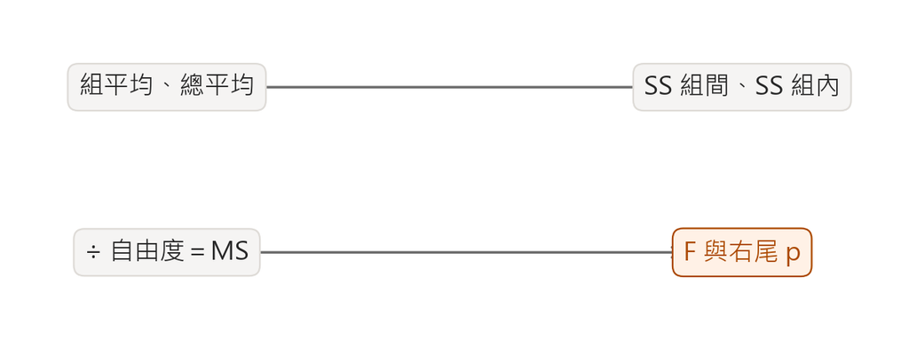

先算平方和，再除以自由度，最後相除得 F。

IMS 2e §22.3.1（MSG、MSE 與 F）；Rosner 8e §12.3（組間、組內平方和）；R `?FDist`；dplyr `?summarise`。

## 用同一個 F 分布查臨界值與 p 值

```r
qf(.95, df1 = 2, df2 = 33)
pf(14.99, df1 = 2, df2 = 33, lower.tail = FALSE)
```

| 給 R 什麼？ | 得到什麼？ |
| --- | --- |
| `qf()`：左側累積機率 .95 | 右尾檢定的臨界值約 **3.28** |
| `pf()`：觀察到的 $F\approx14.99$，取右尾 | $p \approx$ **.000023** |

兩行都用表中的組別自由度 2、殘差自由度 33。

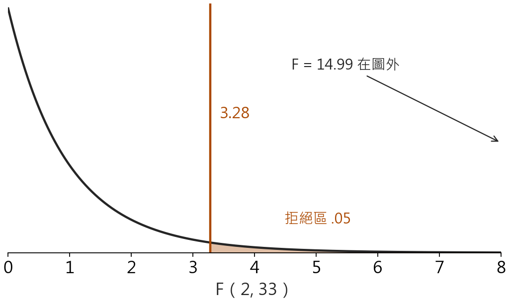

橘線 3.28 右側的著色是 .05 拒絕區。觀察到的 14.99 在圖框右側之外，所以 p 遠小於 .05。

IMS 2e §22.3.2；R `?FDist`。$F$ 值取至小數兩位。

## 練習 1｜組別編號為什麼只占一個自由度？

```r
three <- three |> mutate(code = as.integer(feed))
summary(aov(weight ~ code, data = three))
```

飼料原本有 2 個自由度。改用 1、2、3 的編碼後，為什麼 `code` 只有 1 個自由度？怎麼保留編碼又讓 R 比較三組？

R 將數字 `code` 用作數值變項，估計一條直線的斜率。寫成 `aov(weight ~ factor(code), data = three)`，三個水準就會回到 2 個自由度。

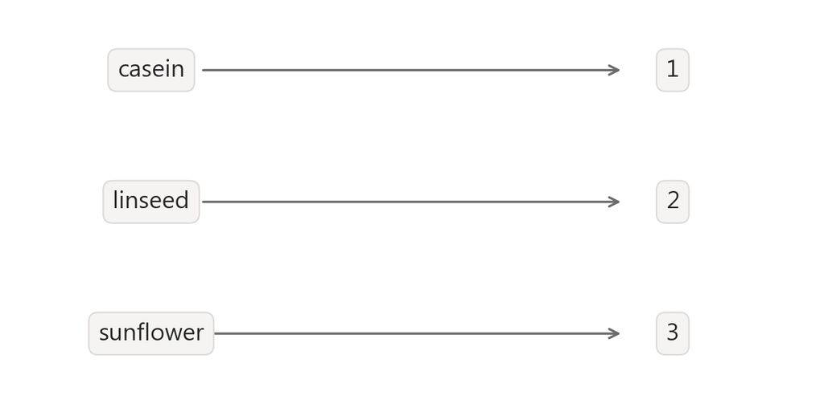

同樣的 1、2、3，可以存成組別編碼。

自編練習；R `?factor`、`?aov`。

## Tukey｜哪一組減哪一組？

```r
TukeyHSD(fit)
```

| 比較 | diff | lwr | upr | p adj |
| --- | --- | --- | --- | --- |
| linseed-casein | −104.83 | −160.50 | −49.16 | .0002 |
| sunflower-casein | 5.33 | −50.34 | 61.00 | .970 |

名稱按左減右讀：葵花籽減酪蛋白 $328.9-323.6\approx5.3$。`lwr`、`upr` 是 Tukey 95% 同時信賴區間（simultaneous confidence interval）的上下限；第二列含 0，未達 .05 顯著。

第一列反過來寫成酪蛋白 − 亞麻籽 = +104.83，區間 49.16 到 160.50：**反向時端點也要反向並變號。**

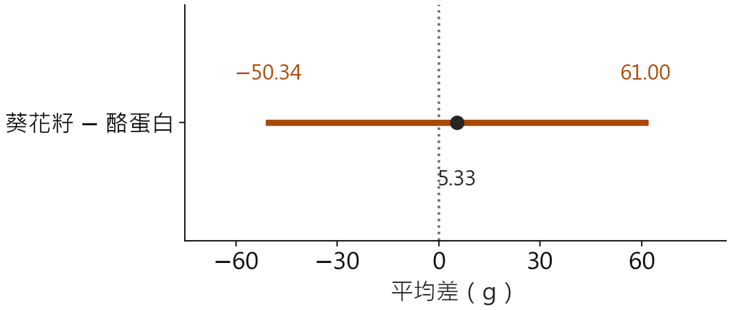

區間跨過 0，包含兩組沒有差的情形。

單因子 Tukey HSD 依 R `?TukeyHSD`。資料：IMS 2e §22.5 練習 5 的三組。

## 自己算一次｜一對的 SE、t、p 與 Tukey 半寬

用組平均 `m` 與組內均方 `ms_error`，計算葵花籽 − 酪蛋白的比較結果。

```r
se <- sqrt(ms_error * (1/12 + 1/12))
t <- (m["sunflower"] - m["casein"]) / se
p <- 2 * pt(-abs(t), df = 33)
min(1, 3 * p)                         # Bonferroni
qtukey(.95, 3, 33) * sqrt(ms_error / 12)  # Tukey 半寬
```

SE 22.69 g、t 0.235、雙尾 p .816；乘 3 超過 1，Bonferroni 報 **1**。Tukey 半寬 **55.67 g**，$5.33\pm55.67$ 就是 `TukeyHSD()` 的 −50.34 到 61.00。

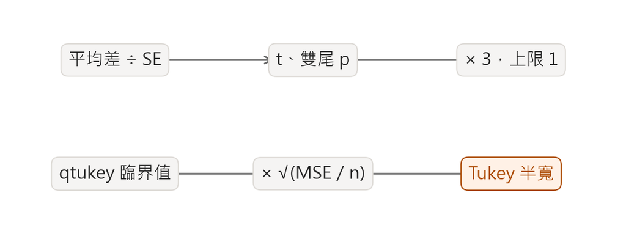

上排算 p 與 Bonferroni，下排算 Tukey 區間半寬。

Rosner 8e Eq. 12.12、12.14（LSD 的 t、Bonferroni）；單因子 Tukey 半寬依 R `?qtukey`。

## 成對 t 檢定｜同一對，兩種 p 值

```r
pairwise.t.test(three$weight, three$feed, p.adjust.method = "none")
pairwise.t.test(three$weight, three$feed, p.adjust.method = "bonferroni")
```

在輸出表找「sunflower」那列、「casein」那欄。

原始 $p\approx.816$（R 印成 0.82），Bonferroni 為 **1**。兩個輸出都用三組合併的標準差，也就是 `ms_error`。

[figure not shown]

Bonferroni 校正看這一批共有幾對。

Rosner 8e Eq. 12.12、12.14（LSD、Bonferroni，上限 1）；R `?pairwise.t.test`。

## 已有六個原始 p 值，怎麼校正？

六個原始 p 值來自四組諮詢的成對比較（N 無諮詢、M 僅冥想、W 僅減重、B 兩者皆有）；完整計算見起始 QMD。先預測：W−N 這一對，兩種方法各會不會通過 .05？

```r
demo_raw <- c("M-N" = .06031758,   "W-N" = .009537725,
              "B-N" = .0003277982, "W-M" = .4539494,
              "B-M" = .06723128,   "B-W" = .2730873)
round(p.adjust(demo_raw, method = "bonferroni"), 3)
round(p.adjust(demo_raw, method = "holm"), 3)
```

| 方法 | W−N 校正後 $p$ | 達 .05 的對數 |
| --- | --- | --- |
| Bonferroni | .057 | 1 |
| Holm | .048 | 2 |

`p.adjust()` 要拿到整批六個 p；只給一個，R 會當成只比一次。W−N 排第 2，Holm 乘 5 得 .048。若先把 .0095 取成 .010，乘 5 會變成 .050，正好落在邊界。

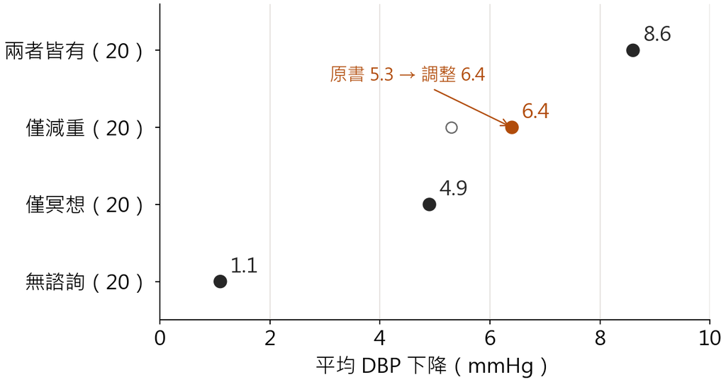

六個 p 來自這四組的兩兩比較。

教學調整資料，改編自 Rosner 8e Table 12.33（僅減重組平均改為 6.4）；p 值依摘要計算。R `?p.adjust`。

## BH｜自己算校正後 p，再對照 `p.adjust()`

將 `demo_raw` 中的原始 p 值排序，再按排名校正。BH 控制偽發現率（FDR）。

```r
n_tests <- length(demo_raw)
ord <- order(demo_raw)
ranked <- demo_raw[ord] * n_tests / seq_len(n_tests)
bh <- pmin(1, rev(cummin(rev(ranked))))
round(bh, 4)
round(p.adjust(demo_raw, method = "BH")[ord], 4)
```

`ranked` 的第 3 個是 .1206。先預測：`bh` 的第 3 個是多少？

兩行都印出 .0020、.0286、.1008、.1008、.3277、.4539。`rev(cummin(rev(...)))` 從最後一個往上取累積最小值；少了這一步，第 3 個會停在 .1206。W−N 的 BH p = .0286，取三位小數為 .029。

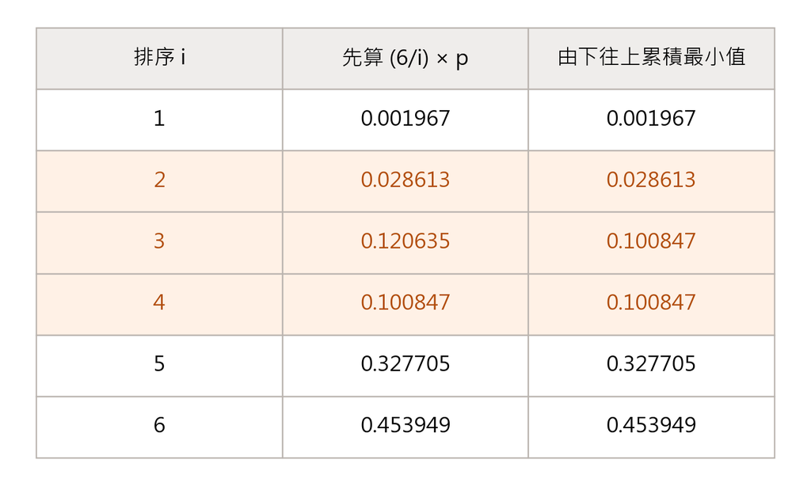

先乘 6/i，再由下往上取累積最小值。

Rosner 8e Eq. 12.17，p. 577（BH）；上限 1 與放回順序依 R `?p.adjust`。教學調整資料，改編自 Rosner 8e Table 12.33。

## 附錄｜心率例：已知目標檢定力，求樣本數

想偵測平均差 5 次／分鐘，標準差估為 10 次／分鐘。採單一樣本雙尾檢定，顯著水準（significance level）.05，目標檢定力（power）.80。

```r
heart <- power.t.test(
  delta = 5, sd = 10, power = .80, type = "one.sample",
  sig.level = .05, strict = TRUE
)
heart$n
```

`delta` 是想偵測的母體平均差，`sd` 是標準差，`strict = TRUE` 計入兩個拒絕尾端。留空 `n`，R 算出 33.37，向上取整為 **34 人**。

[figure not shown]

先給目標差、標準差與檢定力，再求 n。

Week 10 Part 1 心率例；R `?power.t.test`。

## 附錄｜兩個獨立組：$n$ 是每組的人數

網路搜尋例想偵測平均差 .71 分，兩組標準差皆估為 1.154 分。

```r
search <- power.t.test(
  delta = .71, sd = 1.154, power = .80, type = "two.sample",
  sig.level = .05, strict = TRUE
)
ceiling(search$n)
```

回傳 $n\approx42.45$，因此每組 **43 人**，合計 86 人。

門檻提高時，要維持 .80 就得加人。只改這一次檢定的 `sig.level`：`.05/3`（三對 Bonferroni）每組 **57 人**，`.001` 每組 **93 人**。

[figure not shown]

兩組用相同的每組樣本數。

Week 10 Part 1 網路搜尋例；R `?power.t.test`。

## 附錄・練習 2｜每組只有 30 人，檢定力是多少？

網路搜尋實驗每組 30 人，雙尾 $\alpha=.05$，目標平均差 .71 分，標準差 1.154 分。現在該給定哪個引數、留空哪個引數？

```r
power.t.test(
  n = 30, delta = .71, sd = 1.154, type = "two.sample",
  sig.level = .05, strict = TRUE
)$power
```

給定 `n`，留空 `power`。若設定的平均差與標準差成立，檢定力約 **.649**。

[figure not shown]

兩個獨立組，各收 30 人。

自編練習，沿用 Week 10 Part 1 網路搜尋例參數；R `?power.t.test`。

## Slido｜Part Two

[figure not shown]

Slido QR code

https://app.sli.do/event/pEcUD1Jb57Wwf9Ujw3bQRH